# Walter-Lieth Diagrams & the `Climatol` R Package

Christopher W. Beltz (@BeltzEcology)

2020-01-31

Abstract

This is a help file for creating Walter-Lieth climate diagrams in R using the `climatol` package. Walter-Lieth diagrams are used to summarize long-term monthly climate variables over the course of the year. They are standardized in format to increase the ease of interpretation, and aid in comparison between locations or between years. Walter-Lieth diagrams are particularly helpful for identifying water availability and stress to aboveground plant communities. A previous version of this file was utilized as part of a workshop within a course on Global Drylands at the Yale School of Forestry & Environmental Studies in Fall 2017.

*Note: This workshop and the following exercises assume no experience with R or RStudio. However, if you have no previous experience with R it is heavily recommended that you do a quick introduction to R and RStudio. Swirl (https://swirlstats.com/) provides an excellent introduction to R and will conduct its introduction from within R itself. Follow the instructions under Swirl’s “Learn” tab to get started with the introduction.*

*Note: It is recommended that you work through the R markdown file in order your first time through, running individual lines of code or individual code chunks. Reading the text as you do so will help explain the general process and is extremely important for those that have not worked in R before.*

*Note: All files and code can be found on github (https://github.com/cwbeltz/Sketch.001_Climate.Diagram.WL).*

##Set-Up

Install Packages:

```r
#only install if needed
install.packages("climatol")
install.packages("knitr")
install.packages("dplyr")
install.packages("tidyr")
install.packages("lubridate")
```

Load `climatol` package:

```r
library(climatol)
```

Load other packages:

```r
library(knitr)
library(dplyr)
library(tidyr)
library(lubridate)
```

##Workshop Overview

The goal of this workshop is to provide you with the skills to create a Walter-Lieth climate diagram in R for any location within the United States or in North America. In addition, you will be able to create and export PDFs of diagrams that can then be included in presentations, papers, etc.

In order to accomplish this goal, we will use five increasingly complex examples. In these examples, we will: (1) create a quick and simple Walter-Lieth climate diagram (henceforth ‘CD’) using pre-loaded and pre-formatted data. (2) manually enter 1981-2010 climate normals from NOAA and create a CD. (3) download climate normals from Daymet and create a CD. (4) create a set of three CDs simultaneously using ‘bulk downloaded’ PRISM data which we will then manipulate into the correct format within R. (5) create a CD using daily data and then including a calculation of ‘absolute monthly minimum’ temperature, while aggregating our data into 30-year required format for `climatol`.

##Example 1: Required Data Format & a Quick Climate Diagram

In Example 1, we will create a quick CD for Boston, MA (USA). The climate normals for Boston have already been downloaded and converted into a CSV (comma separated values) file.

**Name: Boston, MA**

Years: 1981-2010

Lat/Long: 42.3611° / -71.0571°

Elevation: 5m

Reading data directly into R:

```r
#read in data
Boston_climate.normal <- read.csv("https://raw.githubusercontent.com/cwbeltz/Sketch.001_Climate.Diagram.WL/master/Sketch.001_Climate.Diagram.WL_Example.1_DATA_Boston.MA.csv", as.is=TRUE)

#check data frame
head(Boston_climate.normal)
```

|  | Month | Jan | Feb | Mar | Apr | May | Jun | Jul | Aug | Sep | Oct | Nov | Dec |
| --- | --- | --- | --- | --- | --- | --- | --- | --- | --- | --- | --- | --- | --- |
| 1 | ppt_mm | 92.6 | 90.9 | 117.4 | 108.7 | 94.5 | 102.5 | 95.7 | 92.5 | 93.5 | 107.3 | 112.4 | 107.4 |
| 2 | tmax_C | 2.3 | 3.8 | 7.7 | 13.6 | 19.4 | 24.7 | 27.7 | 26.8 | 22.9 | 16.9 | 11.2 | 5.3 |
| 3 | tmin_C | -6.8 | -5.3 | -1.7 | 3.8 | 8.9 | 14.4 | 17.4 | 16.8 | 12.7 | 6.3 | 1.8 | -3.4 |
| 4 | absmin_C | -6.8 | -5.3 | -1.7 | 3.8 | 8.9 | 14.4 | 17.4 | 16.8 | 12.7 | 6.3 | 1.8 | -3.4 |

Formatting Data for `climatol`:

The `climatol` package requires the climate data to be formatted in a 4x12 (rows x columns) CSV file. Each of the four rows, beginning with the first/top row, should contain monthly variables for precipitation (mm), mean max monthly temperature (C), mean monthly minimum temperature (C), and absolute monthly minimum temperature (C), respectively. Each of the twelve columns should correspond to data for a month of the year beginning with January. *Note: It is permissable within the `climatol` package to name each column by month, creating an additional row - as long as this row is on the top. It will be read in as a header and NOT as data.*

If we look at the header of our data from the code chunk above (i.e. `head()` called in line 74), we can see that the order of our variables matches matches the description from the paragraph above. However, you should also notice that the data frame is 4x13 - meaning that there is currently an extra column present. If you re-read the description of the required format, you will notice that the first column (i.e. the column with the variable names: “ppt_mm”, tmax_C, etc.) is not part of the required format. This column was included to explicit show the orientation of variables within the data table, however we can (and need to) now remove it.

*Note: If you noticed that the 3rd and 4th row (mean monthly minimum temperature and absolute monthly minimum temperature) in the data table above contain identical information, you would be correct! We will address this specifically in Example 5. For the first four examples, we will use the mean monthly minimum temperature as the absolute monthly minimum temperature.*

Removing First Column in Data Frame:

```r
#remove first column with variable names
Boston_climate.normal <- Boston_climate.normal[,-1]

#check data frame
head(Boston_climate.normal)
```

|  | Jan | Feb | Mar | Apr | May | Jun | Jul | Aug | Sep | Oct | Nov | Dec |
| --- | --- | --- | --- | --- | --- | --- | --- | --- | --- | --- | --- | --- |
| 1 | 92.6 | 90.9 | 117.4 | 108.7 | 94.5 | 102.5 | 95.7 | 92.5 | 93.5 | 107.3 | 112.4 | 107.4 |
| 2 | 2.3 | 3.8 | 7.7 | 13.6 | 19.4 | 24.7 | 27.7 | 26.8 | 22.9 | 16.9 | 11.2 | 5.3 |
| 3 | -6.8 | -5.3 | -1.7 | 3.8 | 8.9 | 14.4 | 17.4 | 16.8 | 12.7 | 6.3 | 1.8 | -3.4 |
| 4 | -6.8 | -5.3 | -1.7 | 3.8 | 8.9 | 14.4 | 17.4 | 16.8 | 12.7 | 6.3 | 1.8 | -3.4 |

Create a Walter-Lieth climate diagram:

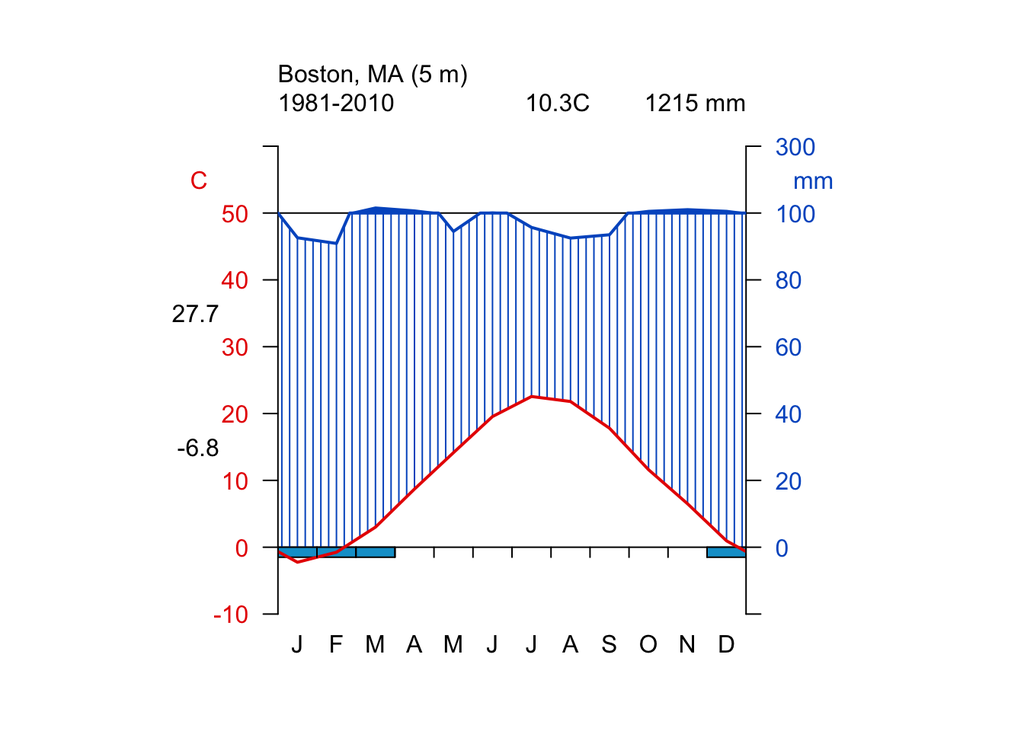

```r
diagwl(Boston_climate.normal, est="Boston, MA", alt=5, per="1981-2010", mlab="en")
```

##Example 2: Entering Data & Exporting the Climate Diagram as a PDF

For this example, we will be locating 30-year Climate Normals on the National Oceanic and Atmospheric Administration (NOAA) data tools on their website.

1981-2010 Normals can be found here: https://www.ncdc.noaa.gov/cdo-web/datatools/normals

Select *monthly normals* > *New York* > *NY City Central Park, NY US*

You should now see a line graph immediately below your selctions showing precipitation and temperature in four different colors. Below that graph is a table of all the climate data you will need for you CD. You will also need some additional information to fill out the diagram, including the years of the normals, the lattitude and longitude, and the elevation.

The current set of normals are 1981-2010; this is the only 30-year normal available currently as part of this tool (at least as of 2020-01-30). The lattitude, longitude, and altitude can be found in the “Station Report”; a link to this report is locate to the right of the “NY CITY CENTRAL PARK, NY US” header.

Once you hace those three pieces of information, you can find the climate data in the table on the bottom of the web page. Note the format of the data; it includes 12 months of data for four variables. We actually don’t need the average monthly temperature, but it may be easiest to copy/paste the entire table from the NOAA website and then remove the average temperatures. Manually enter (or copy/paste) the data into the correct format shown in Example 1.

*Note: If you are using Microsoft Excel, `paste special` and `transpose` may be helpful to getting the data into the correct format.*

*Note: Remember to order the rows of data correctly, removing the average monthly temperature and using the minimum temperature in two places (i.e., minimum and abs minimum).*

*Note: You will need to convert temperature and precipitation to SI units.* *(32°F − 32) × 5/9 = 0°C* *1 inch x 25.4 = 25.4 mm*

**Name: New York City, NY**

Years: 1981-2010

Lat/Long: 40.7790° / -73.9693°

Elevation: 42.7m

```r
#NYC data for walk-through only. REMOVE THIS CHUNK for any actual assignments.

#read in NYC data
NYC_climate.normal <- read.csv("https://raw.githubusercontent.com/cwbeltz/Sketch.001_Climate.Diagram.WL/master/Sketch.001_Climate.Diagram.WL_Example.2_DATA_NYC.NY.csv", as.is=TRUE)

#check data frame
head(NYC_climate.normal)
```

|  | MONTH | X1 | X2 | X3 | X4 | X5 | X6 | X7 | X8 | X9 | X10 | X11 | X12 |
| --- | --- | --- | --- | --- | --- | --- | --- | --- | --- | --- | --- | --- | --- |
| 1 | PRECIP | 92.7 | 78.5 | 110.7 | 114.3 | 106.4 | 112.0 | 116.8 | 112.8 | 108.7 | 111.8 | 102.1 | 101.6 |
| 2 | MAX TMP | 3.5 | 5.3 | 9.8 | 16.2 | 21.6 | 26.3 | 28.9 | 28.1 | 24.0 | 17.7 | 12.1 | 6.1 |
| 3 | MIN TMP | -2.8 | -1.7 | 1.8 | 7.1 | 12.2 | 17.6 | 20.4 | 19.9 | 16.0 | 10.0 | 5.3 | 0.0 |
| 4 | MIN TMP | -2.8 | -1.7 | 1.8 | 7.1 | 12.2 | 17.6 | 20.4 | 19.9 | 16.0 | 10.0 | 5.3 | 0.0 |

*Note: R may add an X in front of the numbers that reflect the month in the column header. This is not a problem, at least for this use case, and we can ignore it. This is a common occurence when using `read.csv` to read in data that has columns names that begin with or are a number.*

Create Walter-Lieth diagram:

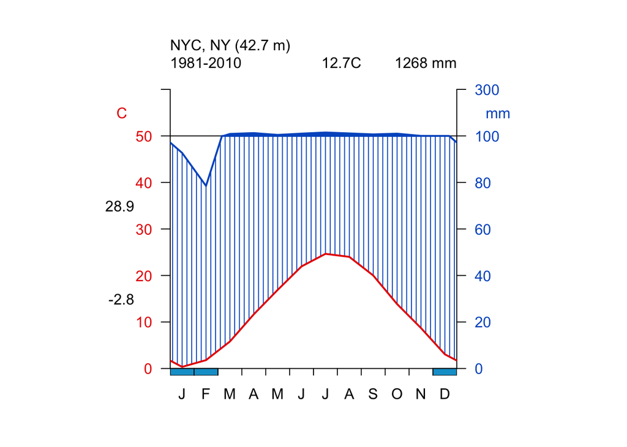

```r
diagwl(NYC_climate.normal[,-1], est="NYC, NY", alt=42.7, per="1981-2010", mlab="en")
```

To export the CD as a PDF, two additional functions will be needed: `pdf` and `dev.off`. These will create the PDF, insert the CD using `diagwl` and the indicate that the PDF is finished.

Walter-Lieth diagram exported in a PDF format:

```r
#open PDF
pdf("CD_NYC.pdf", width=6.0, height=8.0)

diagwl(NYC_climate.normal[,-1], est="NYC, NY", alt=42.7, per="1981-2010", mlab="en")

#close PDF
dev.off()
```

##Example 3: Creating a Climate Diagram using data from DAYMET

DAYMET (https://daymet.ornl.gov/) provides estimates for seven weather parameters for all of North America, inclusive of Canadao, Mexico, and the United States. Begin by loading installing (if needed) and loading the `daymetr` package which will all you to download the needed climate data.

Install the `daymetR` package:

```r
#only install if needed
install.packages("daymetr")
```

Load `daymetr` package:

```r
library(daymetr)
```

Download daily DAYMET climate data for Vancouver, Canada:

```r
Vancouver_data <- download_daymet(site = "VancouverCAN",
                lat = 49.2827,
                lon = -123.1207,
                start = 1981,
                end = 2010,
                internal = TRUE,
                simplify = TRUE) #simplify returns tidy data, ready for analysis
```

```
## Done !
```

Subset location/site parameters:

```r
Vancouver_site <- Vancouver_data[1,1:5]
```

Remove extraneous data:

```r
Vancouver_sub <- Vancouver_data[(Vancouver_data$measurement=="prcp..mm.day." | Vancouver_data$measurement=="tmax..deg.c." | Vancouver_data$measurement=="tmin..deg.c."),]
```

Create ‘month’ variable from day-of-year:

```r
Vancouver_sub$year.yday <- paste(Vancouver_sub$year, Vancouver_sub$yday, sep="-")

Vancouver_sub$month <- month(as.POSIXlt(Vancouver_sub$year.yday, format="%Y-%j"), label=TRUE)
```

Transform DAYMET data to wide format:

```r
Vancouver_sub <- pivot_wider(Vancouver_sub, id_cols=c(year, yday, month), names_from=measurement, values_from=value)
```

Condense daily data to 30-yr monthly climate normals:

```r
#to means for each month within year
tmp.mod1_Van <- Vancouver_sub %>% group_by(year, month) %>% summarize(PPT_mm=sum(prcp..mm.day.), Tmax_C=mean(tmax..deg.c.), Tmin_C=mean(tmin..deg.c.), Tabs_C=min(tmin..deg.c.))

#to means for each month across years
Vancouver_climate.normal <- tmp.mod1_Van %>% group_by(month) %>% summarize(PPT_mm=mean(PPT_mm), Tmax_C=mean(Tmax_C), Tmin_C=mean(Tmin_C), Tabs_C=min(Tabs_C))
```

Put calculated 30-yr monthly climate normals into correct format:

```r
#remove month in left column
Vancouver_climate.normal <- Vancouver_climate.normal[,-1]

Vancouver_climate.normal <- as.data.frame(t(Vancouver_climate.normal), stringsAsFactors = FALSE)
```

Get site information for Vancouver:

```r
Vancouver_site
```

| site | tile | latitude | longitude | altitude |
| --- | --- | --- | --- | --- |
| VancouverCAN | 12449 | 49.2827 | -123.1207 | 34 |

Create Walter-Lieth diagram:

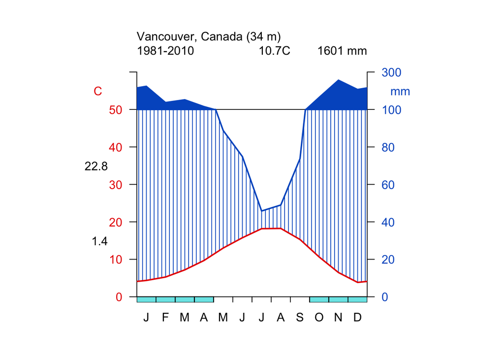

```r
diagwl(Vancouver_climate.normal, est="Vancouver, Canada", alt=34, per="1981-2010", mlab="en")
```

Remove all files from Example 3:

```r
rm(tmp.mod1_Van, Vancouver_data, Vancouver_site, Vancouver_sub)
```

##Example 4: Three locations using PRISM

For this example, we will use PRISM data instead of either NOAA or DAYMET. The benefit of PRISM is that it allows you to choose any location within the United States, regardless of whether there is a meteorological station at that location. In addition, PRISM datasets are available in 30-year climate normals for the 1981-2010 period and these are able to be downloaded in CSV format for multiple locations at one time. However, we will still have to wrangle the data into the same format as in Example 1 (i.e. a 4x12 matrix) in order to use `climatol`.

**Name: Cheyenne, WY**

Elevation: 1856m

Years: 1981-2010

Lat/Long: 41.1400°, -104.8202° (from latlong.net)

**Name: Thunder Basin National Grassland (near Bill, WY)**

Elevation: 1338m

Years: 1981-2010

Lat/Long: 43.43395497°, -104.931518° (from Garmin handheld)

**Name: Central Plains Experimental Range (near Nunn, CO)**

Elevation: 1648m

Years: 1981-2010

Lat/Long: 40.81882498°, -104.732638° (from Garmin handheld)

Download GPS locations with lat/long and upload to PRISM website:

```r
locations <- read.csv("https://raw.githubusercontent.com/cwbeltz/Sketch.001_Climate.Diagram.WL/master/Sketch.001_Climate.Diagram.WL_LOCATIONS_Lat.Long.csv", as.is=TRUE)

#create csv on your computer
write.table(locations, file="LOCATIONS_PRISM_UPLOAD.csv", row.names=F, col.names=F, sep=",")

rm(locations)
```

Now that you have the lat/long of your locations, use the PRISM Data Explorer and upload the CSV file, “LOCATIONS_PRISM_UPLOAD.csv.” Go to http://prism.nacse.org/explorer/bulk.php# and use the “Open Locations File” button in the middle of the page to upload the locations file. Make sure to select the following: 30-yr normals in 800m resolution, SI (metric), interpolate values, precipitation, minimum temperature, and maximum temperature. After making those selections, upload the locations file. Click on “Prepare & Download Time Series” and the download should begin. The file will be named something similar to “PRISM_ppt_tmin_tmax_30yr_normal_800m_monthly_normals.csv.”

You may now use Excel or another spreadsheet program to manually manipulate the data into the correct format or you can use/modify the script below to do so.

*Note: If you use this code for to create diagrams for other sites, make sure to include an intelligable site name. This name will be carried through as part of the final file name fed into `climatol`.

Read in PRISM data:

```r
#Note you will need to add the correct file path on your computer here
Ex4.orig <- read.csv("https://raw.githubusercontent.com/cwbeltz/Sketch.001_Climate.Diagram.WL/master/PRISM_ppt_tmin_tmax_30yr_normal_800m_monthly_normals.csv", skip=10) #skip 10 rows of metadata
```

Manipulating the CSV file of PRISM into format for `climatol`:

*Note: The code below could be built into a single function. I have left it as a single manipulation per line so that you can follow each step more easily, if you would like to.*

```r
loc.elev <- data.frame(Loc=unique(Ex4.orig$Name), elev=unique(Ex4.orig$Elevation..m.)) #create file with location name and elevation to reference later

tmp.manip <- split(Ex4.orig, Ex4.orig$Name, drop = TRUE) #split PRISM data by location name
tmp.manip <- lapply(tmp.manip, function(x) x[-13,-c(1:5)]) #remove row 13 (annual data) and columns 1 to 5 from all dataframes
tmp.manip <- lapply(tmp.manip, setNames, c("ppt", "Tmin", "Tmax")) #simplify column names
tmp.manip <- lapply(tmp.manip, function(x) {rownames(x) <- NULL; x}) #remove rownames
tmp.manip <- lapply(tmp.manip, function(x) x[,c(1,3,2)]) #reorder columns for climatol format
tmp.manip <- lapply(tmp.manip, function(x) {cbind(x, Tabs = x$Tmin)}) #copy Tmin as Tabs
tmp.manip <- lapply(tmp.manip, t) #transpose data

list2env(setNames(tmp.manip, sprintf("PRISM_%s", gsub("\\s+", "_", names(tmp.manip)))), .GlobalEnv) #convert list of PRISM sites from split into dataframes for individual locations
```

```
## <environment: R_GlobalEnv>
```

```r
rm(Ex4.orig, tmp.manip)
```

Create three Walter-Lieth graphics in a single PDF:

```r
#open PDF
pdf("Beltz_2017_FES634_Walter.Lieth_TRIPLE_DIAGRAM.pdf", width=6.0, height=6.0)

#Central Plains Experimental Range near Nunn, CO
diagwl(PRISM_Central_Plai, est="CPER near Nunn, CO", alt=1651, per="1981-2010", mlab="en")

#Cheyenne, WY
diagwl(PRISM_Cheyenne, est="HPGRS in Cheyenne, WY", alt=1857, per="1981-2010", mlab="en")

#Thunder Basin National Grasslands near Bill, WY
diagwl(PRISM_Thunder_Basi, est="TBNG near Bill, WY", alt=1338, per="1981-2010", mlab="en")

#close PDF
dev.off()
```

Remove all files from Example 4:

```r
rm(list=ls(pattern="PRISM_"), loc.elev)
```

##Example 5: Obtaining ‘absolute minimum temperature’

Thus far we have used ‘mean minimum monthly temperature’ in the place of ‘absolute minimum temperature.’ While this can be a close proxy and allows for the quick generation of Walter-Lieth diagrams using climate normals, absolute minimum temperature gives us a better indication of days with frost. To calculate absolute minimum temperature, we need to go back to daily data.

Read in the FES daily PRISM data:

*Note: You should have almost 11,000 observations.*

```r
#Note you will need to add the correct file path on your computer here
Ex5.orig <- read.csv("https://raw.githubusercontent.com/cwbeltz/Sketch.001_Climate.Diagram.WL/master/PRISM_ppt_tmin_tmax_stable_4km_19810101_20101231_41.3171_-72.9236.csv", skip=10)
```

View FES daily PRISM data:

```r
head(Ex5.orig)
```

|  | Date | ppt..mm. | tmin..degrees.C. | tmax..degrees.C. |
| --- | --- | --- | --- | --- |
| 1 | 1981-01-01 | 0.00 | -12.3 | -4.4 |
| 2 | 1981-01-02 | 1.97 | -7.8 | -1.5 |
| 3 | 1981-01-03 | 0.00 | -13.9 | 0.5 |
| 4 | 1981-01-04 | 1.77 | -19.5 | -9.9 |
| 5 | 1981-01-05 | 0.00 | -19.6 | -13.3 |
| 6 | 1981-01-06 | 0.00 | -13.8 | -2.5 |

Extract year, month, & day with `lubridate`:

```r
Ex5.orig$Year <- year(Ex5.orig$Date)
Ex5.orig$Month <- month(Ex5.orig$Date)
Ex5.orig$Day <- day(Ex5.orig$Date)

Ex5.orig <- setNames(Ex5.orig, c("Date", "ppt_mm", "Tmin_C", "Tmax_C", "Year", "Month", "Day")) #simplify column names

head(Ex5.orig)
```

|  | Date | ppt_mm | Tmin_C | Tmax_C | Year | Month | Day |
| --- | --- | --- | --- | --- | --- | --- | --- |
| 1 | 1981-01-01 | 0.00 | -12.3 | -4.4 | 1981 | 1 | 1 |
| 2 | 1981-01-02 | 1.97 | -7.8 | -1.5 | 1981 | 1 | 2 |
| 3 | 1981-01-03 | 0.00 | -13.9 | 0.5 | 1981 | 1 | 3 |
| 4 | 1981-01-04 | 1.77 | -19.5 | -9.9 | 1981 | 1 | 4 |
| 5 | 1981-01-05 | 0.00 | -19.6 | -13.3 | 1981 | 1 | 5 |
| 6 | 1981-01-06 | 0.00 | -13.8 | -2.5 | 1981 | 1 | 6 |

Remove original date column:

```r
Ex5.orig <- Ex5.orig[,-1]

head(Ex5.orig)
```

|  | ppt_mm | Tmin_C | Tmax_C | Year | Month | Day |
| --- | --- | --- | --- | --- | --- | --- |
| 1 | 0.00 | -12.3 | -4.4 | 1981 | 1 | 1 |
| 2 | 1.97 | -7.8 | -1.5 | 1981 | 1 | 2 |
| 3 | 0.00 | -13.9 | 0.5 | 1981 | 1 | 3 |
| 4 | 1.77 | -19.5 | -9.9 | 1981 | 1 | 4 |
| 5 | 0.00 | -19.6 | -13.3 | 1981 | 1 | 5 |
| 6 | 0.00 | -13.8 | -2.5 | 1981 | 1 | 6 |

Summarize data by year & month:

```r
tmp.mod1 <- Ex5.orig %>% group_by(Year, Month) %>% summarize(sum(ppt_mm), mean(Tmax_C), mean(Tmin_C), min(Tmin_C))

colnames(tmp.mod1) <- c("Year", "Month", "ppt_mm", "Tmax_C", "Tmin_C", "Tabs_C")
head(tmp.mod1)
```

| Year | Month | ppt_mm | Tmax_C | Tmin_C | Tabs_C |
| --- | --- | --- | --- | --- | --- |
| 1981 | 1 | 17.08 | -1.183871 | -11.658065 | -20.6 |
| 1981 | 2 | 168.00 | 7.150000 | -4.053571 | -16.0 |
| 1981 | 3 | 25.56 | 7.874194 | -1.887097 | -9.8 |
| 1981 | 4 | 96.90 | 16.156667 | 4.806667 | -2.2 |
| 1981 | 5 | 85.46 | 21.574194 | 8.990323 | 1.9 |
| 1981 | 6 | 49.48 | 25.920000 | 14.630000 | 8.5 |

Summarize data by month to get 30-yr climate normals with *absolute minimum temperature*:

```r
tmp.mod2 <- tmp.mod1 %>% group_by(Month) %>% summarize(mean(ppt_mm), mean(Tmax_C), mean(Tmin_C), min(Tabs_C))

colnames(tmp.mod2) <- c("Month", "ppt_mm", "Tmax_C", "Tmin_C", "Tabs_C")
tmp.mod2 <- tmp.mod2[,-1]

str(tmp.mod2)
```

```
## Classes 'tbl_df', 'tbl' and 'data.frame':    12 obs. of  4 variables:
##  $ ppt_mm: num  93.5 85.1 113.2 122.1 104 ...
##  $ Tmax_C: num  2.9 4.54 8.48 14.7 20.32 ...
##  $ Tmin_C: num  -6.5 -4.99 -1.21 4.27 9.44 ...
##  $ Tabs_C: num  -22.8 -20 -15 -8.4 -0.8 5 8.9 5.4 2.2 -3.8 ...
```

Transpose dataframe to `climatol` format:

```r
tmp.mod3 <- t(tmp.mod2)

head(tmp.mod3)
```

```
##              [,1]       [,2]       [,3]       [,4]       [,5]      [,6]
## ppt_mm  93.506000  85.058333 113.234333 122.118667 103.985667 103.07767
## Tmax_C   2.895484   4.539692   8.484301  14.699889  20.324839  25.23078
## Tmin_C  -6.495161  -4.989754  -1.211720   4.271889   9.442151  14.82044
## Tabs_C -22.800000 -20.000000 -15.000000  -8.400000  -0.800000   5.00000
##            [,7]     [,8]      [,9]     [,10]      [,11]      [,12]
## ppt_mm 97.46467 99.85100 101.17733 119.44367 107.890000 103.098000
## Tmax_C 28.30688 27.68473  23.77500  17.52280  11.641333   5.453548
## Tmin_C 18.05720 17.38882  13.10467   6.56871   1.944667  -3.202043
## Tabs_C  8.90000  5.40000   2.20000  -3.80000 -10.800000 -19.700000
```

Create Walter-Lieth diagram of New Haven, CT:

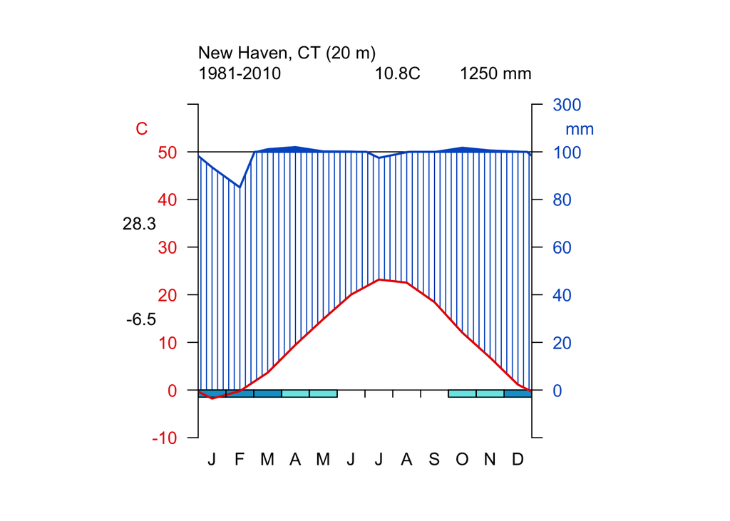

```r
diagwl(tmp.mod3, est="New Haven, CT", alt=20, per="1981-2010", mlab="en")
```

Remove all files from Example 5:

```r
rm(list=ls(pattern="tmp."), Ex5.orig)
```

##Additional Resources

**Climatol-specific resources and package notes**

http://www.climatol.eu/

**“How to Build a Climate Diagram in R”**

http://nestcities.blogspot.com/2013/10/how-to-build-climate-diagram-in-r.html

**Organization of Climate Diagrams and Typical Types**

*Note: This diagram refers to years of temperature/precipitation collection rather than collection period.*

https://www.zoolex.org/page/walter/

**PRISM: Data Explorer**

http://prism.nacse.org/explorer/

**Daymet Climate Summaries**

https://daymet.ornl.gov/